# TMS User Handbook

Transport Management System — a guide for new users

Last updated 01 September 2026

T

TMS

Transport Management System · Logistics ERP

# 1 Before you begin

## 1.1 What this system is

TMS runs a road-freight business end to end. A customer books a load, you put a truck and driver on it, the system produces the paperwork that has to travel with the goods, tracks the vehicle, captures the signed delivery proof, raises the invoice, and records the payment. Alongside that it keeps the masters those operations depend on — branches, customers, vendors, vehicles, drivers, staff — and gives customers and vendors their own limited view.

**The one thing worth understanding before anything else** is the chain that runs through the whole system:

BookingVehicle allocationConsignment (LR)E-way billDispatch & trackingPODInvoicePayment

Every screen in the app is either a step on that chain, a master the chain reads from, or a report over what the chain produced. If you can place a screen on that line, you understand what it is for.

Each link also *gates* the next one. You cannot allocate a vehicle to a booking that was never confirmed; you cannot invoice a consignment that has no signed POD. Those gates are the system doing its job, not getting in your way — Why did it say no? explains each one.

## 1.2 Signing in

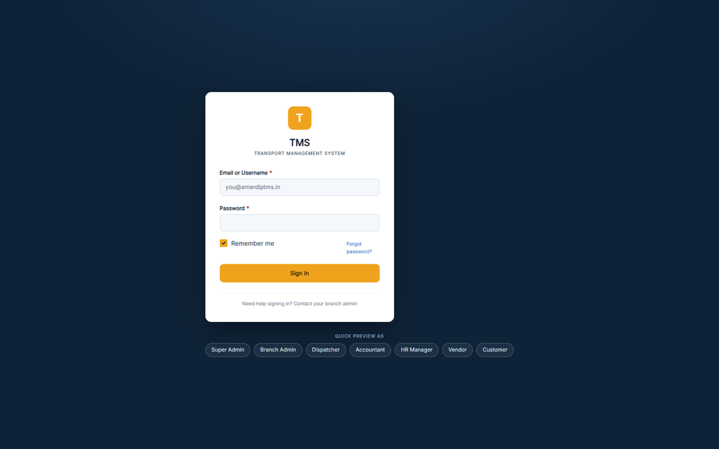

The sign-in screen. Enter your work email and password, or use a Quick preview chip to explore a role.

You can sign in with your full email address or just the part before the `@` — `amardip.singh` and `amardip.singh@amardiptms.in` both work.

If your account has been suspended the screen says so. If your credentials are wrong it says only that they were not recognised — it will not tell you whether the address exists, which is deliberate.

**Forgot your password?** There is no self-service reset. Your branch admin issues a new temporary password from **Administration → Users**.

### Demo accounts

This build ships with generated demo data. Every seeded account uses the same password, `tms@2026`:

| Role | Email | Accounts |
| --- | --- | --- |
| Super Admin | amardip.singh@amardiptms.in | 1 |
| Branch Admin | vikram.chauhan@amardiptms.in | 17 |
| Operations Manager | shalini.wankhede@amardiptms.in | 24 |
| Booking Executive | anil.nair@amardiptms.in | 72 |
| Dispatcher | kiran.kulkarni.1@amardiptms.in | 19 |
| Accountant | ganesh.malhotra@amardiptms.in | 11 |
| HR Manager | arif.kamble@amardiptms.in | 4 |

The **Quick preview as** chips under the sign-in card are a shortcut for exploring: each one signs you straight in as a representative account for that role, including the Customer and Vendor portals. They exist so you can see how the system looks to each kind of user without juggling passwords. A real deployment turns them off by setting `TMS_DEMO_LOGIN=false`.

# 2 Finding your way around

## 2.1 The shell

Every screen sits in the same frame, so once you have learned it you have learned all thirty.

[figure not shown]

The Dashboard, showing the standard frame: navigation rail on the left, page header and search along the top, content below.

**The left rail** is your navigation, grouped by what the screens are for — Administration, Relationships, Operations, Fleet & People, Support, Accounts, HRMS, Insights, System. Groups with a chevron expand to reveal sub-screens; only one group is open at a time. **You will not see all of these.** The rail only shows what your role is allowed to open, so a shorter list is normal, not a fault.

**Your name sits at the bottom of the rail**, with your role beneath it. The icon beside it signs you out.

**The top bar** carries a breadcrumb showing where you are, the page title, global search, help, notifications, and your account.

## 2.2 Patterns you will see everywhere

The app reuses about six layouts. Learning them here saves relearning them on every screen.

### Stat cards

Cards with a **coloured left edge** are asking for attention: amber for something approaching a deadline, red for something past it, green for something comfortably in hand.

Where a card says **30 days** it means a rolling window ending today, not the calendar month. That is deliberate: a month-to-date figure reads zero on the 1st of the month, which looks like a broken feed rather than a new period.

### Master–detail

Most reference screens put a list on the left and a detail panel on the right. **Click any row** to load it into the panel. Until you do, the panel shows a placeholder — that is the screen waiting for you, not an error.

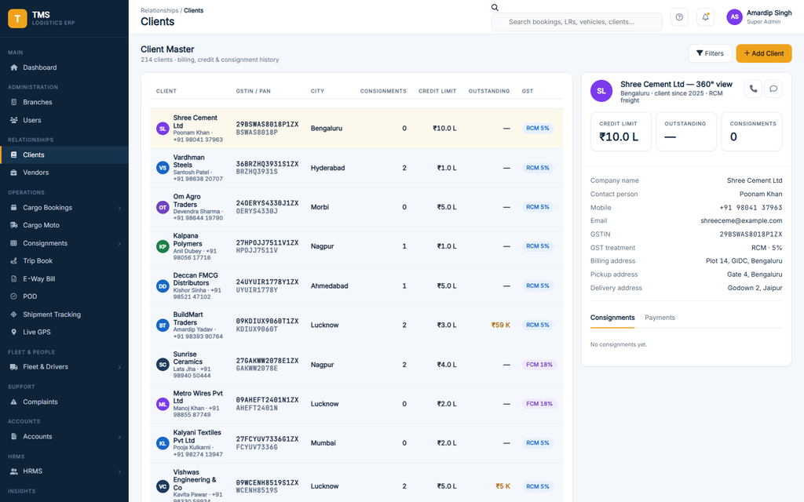

Clients, with a row selected. The 360° panel on the right shows everything about that customer: credit, outstanding balance, addresses, and their recent consignments.

### Kanban boards

Two screens — Cargo Moto and Complaints — show work as cards in columns, one column per stage. Cards move left to right as work progresses. **Click a card** to open its detail. A coloured stripe down the left edge of a card flags priority or a breached deadline.

### Status pills

Small coloured badges carry status everywhere in the app, and the colours mean the same thing on every screen:

| Colour | Meaning | Examples |
| --- | --- | --- |
| green | Done, healthy, or available | Delivered, Paid, Available, Approved, Active |
| blue | Confirmed and moving | Confirmed, Vehicle Allocated, Dispatched, Sent, Verified |
| purple | On the road | In Transit |
| orange | Needs attention soon | Expiring Soon, Uploaded, Partially paid, Maintenance, On leave |
| red | Blocked, overdue, or breached | Expired, Overdue, Cancelled, past SLA |
| grey | Not started, or inactive | Draft, Pending, Unassigned, Inactive |

### Timelines

Where something moves through fixed stages — a consignment, a payroll run — the app draws a vertical timeline. A green tick is a completed step, an amber numbered dot is where the item is now, and hollow grey dots are still ahead.

### Callouts

Tinted boxes explain a rule or warn about a consequence. Blue is information, amber is a caution, red means something is blocked, green confirms.

# 3 The core workflow

This section walks one load from order to cash. If you read nothing else, read this — it is the job.

## 3.1 Step 1 · Take the booking

**Operations → Cargo Bookings → New Booking**

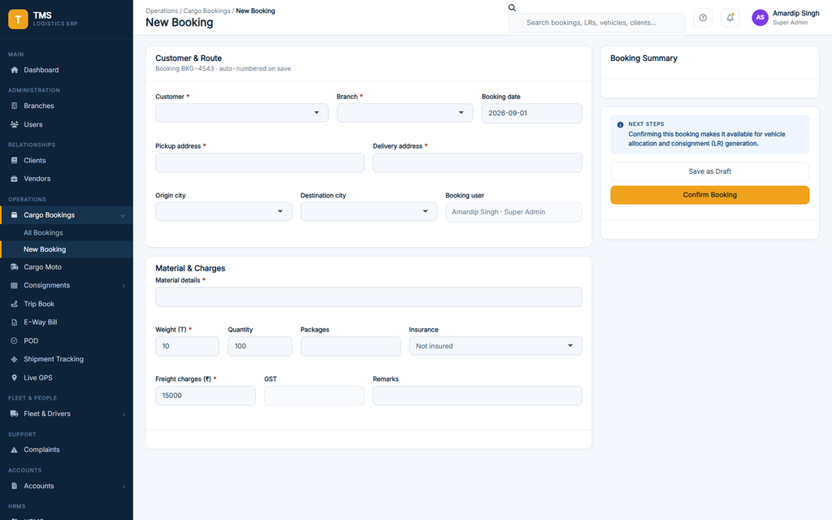

The New Booking form. The summary panel on the right totals the charges as you type.

Pick the **customer** first. Doing so fills in their pickup and delivery addresses from the customer master and sets the GST treatment for the job — you do not choose the tax rate, it comes from the customer’s record.

Fill in origin and destination. As soon as both are set, the form checks the **pin-code route master** and tells you whether the lane is serviceable and how many days transit you can promise. If the lane is not mapped it says so, and you should not quote a delivery date until it is.

Then material, weight, packages, insurance and freight. The right-hand summary totals freight + GST + insurance live.

Finish with one of two buttons:

- **Save as Draft** parks it. Drafts are not visible to dispatch and cannot be allocated a vehicle.
- **Confirm Booking** releases it into operations. This is the one you want when the customer has committed.

The booking number is allocated when you save — you do not type it.

## 3.2 Step 2 · Put a truck on it

**Operations → Cargo Moto**

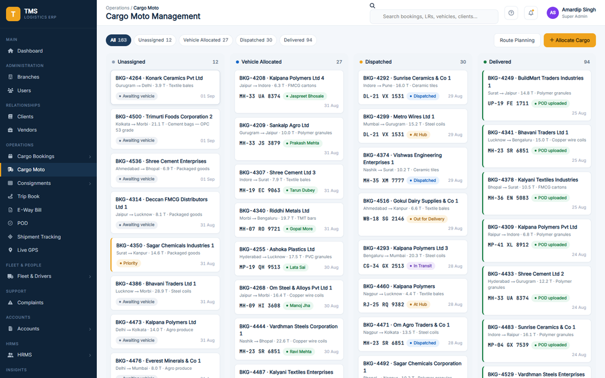

Cargo Moto — the dispatcher’s board. Every confirmed booking sits in one of four columns according to how far it has got.

This board is the same bookings you just created, arranged by how far they have progressed:

- **Unassigned** — confirmed, waiting for a vehicle
- **Vehicle Allocated** — truck and driver assigned, not yet moving
- **Dispatched** — on the road
- **Delivered** — arrived, POD may still be outstanding

Click **+ Allocate Cargo** (or open an unassigned card and choose *Allocate vehicle*).

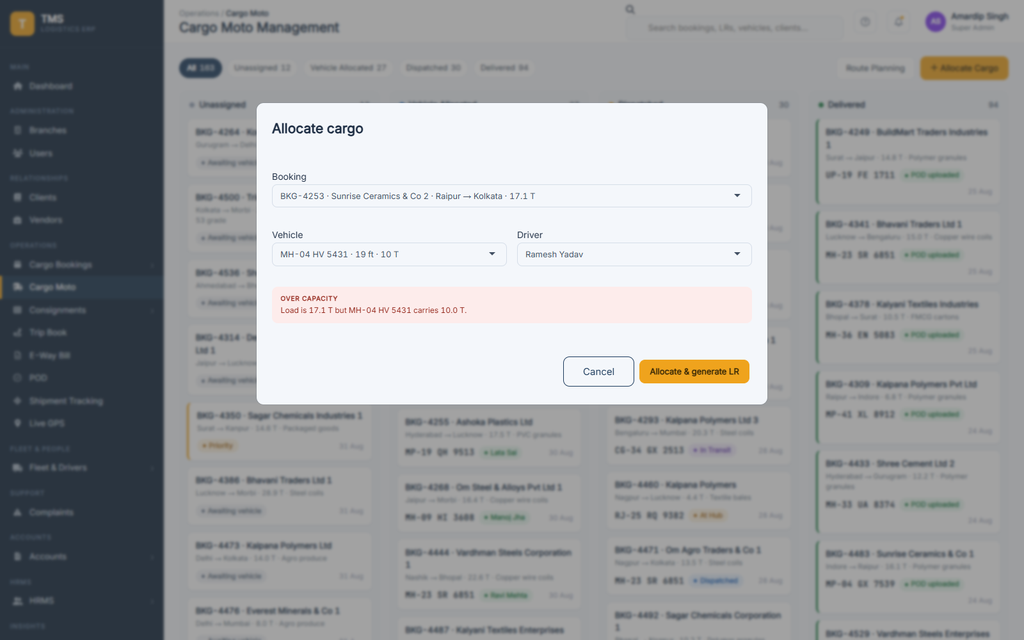

The allocation dialog. It checks capacity, licence and vehicle documents before it will let you commit.

Choose the booking, a vehicle and a driver. Before you can save, the dialog tells you what it found:

- **green** — the load fits and everything is in date; it shows you the spare capacity
- **amber** — the driver’s licence expires within 30 days; you may proceed
- **red** — the load is heavier than the truck, or a vehicle document has expired; **allocation is refused**

Saving does three things at once: it creates the **trip**, generates the **consignment and its LR number**, and moves the booking to *Vehicle Allocated*. You do not create those separately.

## 3.3 Step 3 · The consignment and its LR

**Operations → Consignments → Consignment (LR)**

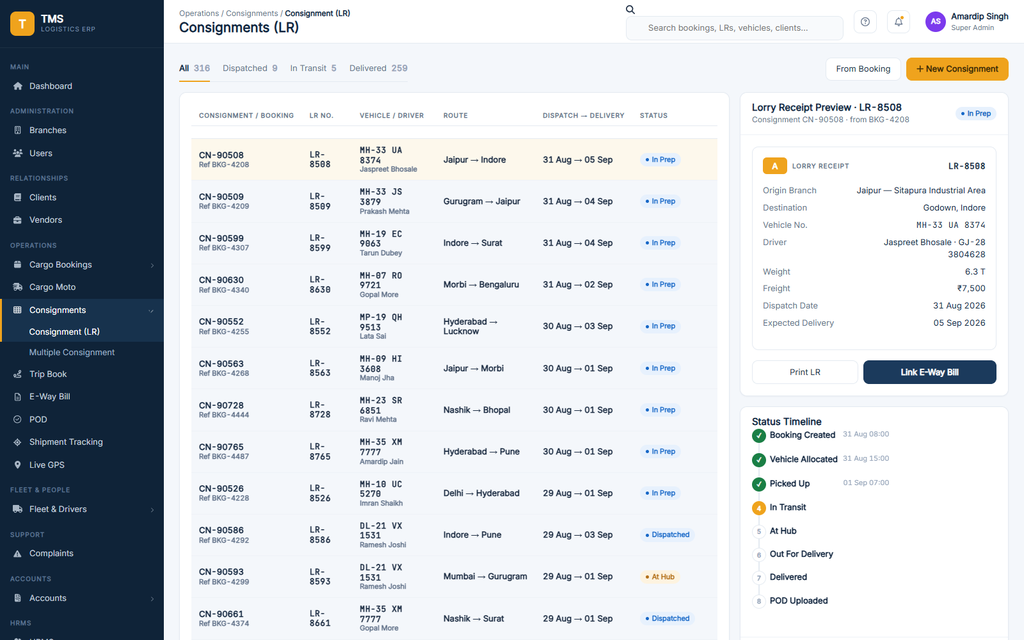

The consignment register, with the lorry receipt preview and status timeline for the selected row.

Each consignment carries **two numbers**, and they are not interchangeable:

- **CN-xxxxx** is the internal record.
- **LR-xxxx** is the **lorry receipt** — the document the driver carries and the consignee signs. This is the number customers quote.

Select a row and the right-hand panel shows the LR ready to print, plus a timeline of where the consignment has got to. **Print LR** sends it to the print queue; the driver cannot leave without it.

### Splitting and consolidating

**Operations → Consignments → Multiple Consignment**

[figure not shown]

Split and consolidation. One booking dropped at several points, or several bookings sharing one truck.

Two situations the simple one-booking-one-truck model does not cover:

- **One booking → many consignments (split).** A single pickup dropped at several delivery points. Each child gets its own CN and LR and its own e-way bill, but they all keep the parent booking reference so the customer gets one bill.
- **Many bookings → one vehicle (consolidation).** Several loads sharing a truck down the same corridor. The panel shows capacity used against capacity available, and warns when there is only a little headroom left before the dispatch cut-off.

## 3.4 Step 4 · The e-way bill

**Operations → E-Way Bill**

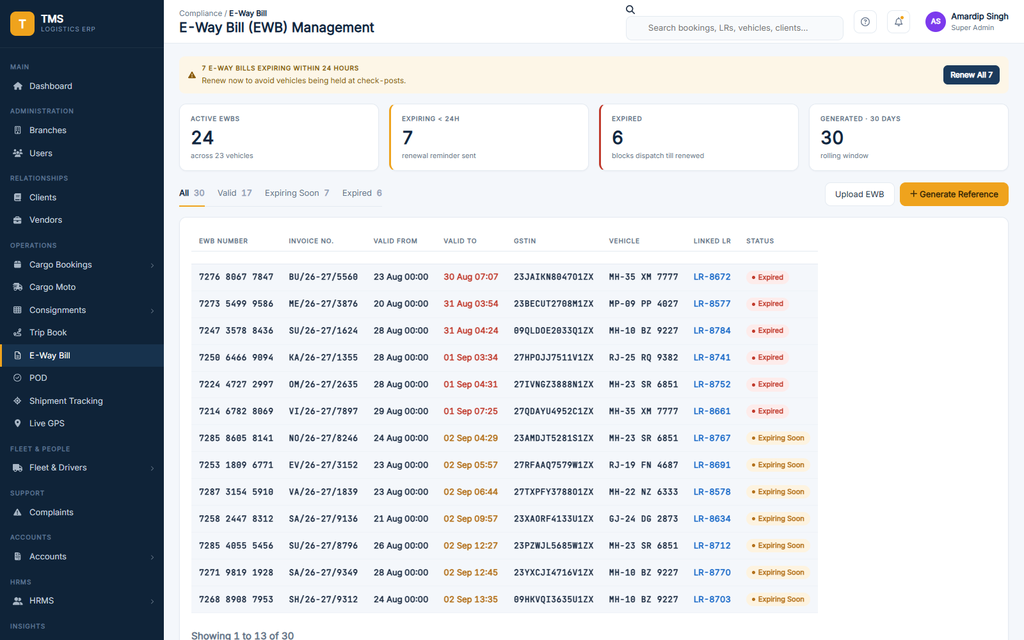

E-way bill management. The screen leads with what is about to expire, because that is what stops trucks.

Under GST, a consignment over the threshold must carry a valid e-way bill, and its validity is **distance-based and expires**. An expired bill gets the vehicle held at a check-post, which is why this screen leads with the expiry queue rather than the register.

- **Expiring < 24h** — renew these today. The banner across the top offers **Renew All**.
- **Expired** — the vehicle cannot legally move on that consignment until the bill is extended.

Extending adds validity based on the distance still to run.

Only consignments actually on the road appear here. Once a consignment is delivered its bill is spent and drops out of the register.

> **In this build the GST Suvidha Provider is not connected.** Generating a bill records a locally-generated reference so the workflow is complete, but nothing is filed with the government portal. The screen says so when you generate.

## 3.5 Step 5 · Watch it move

**Operations → Live GPS** shows the whole fleet on a map.

[figure not shown]

Click a vehicle for its speed, driver, route, ETA and current LR. The **Route Deviation** panel flags any vehicle off its planned corridor and offers to alert the driver.

**Operations → Shipment Tracking** answers the question a customer actually asks: *where is my stuff?*

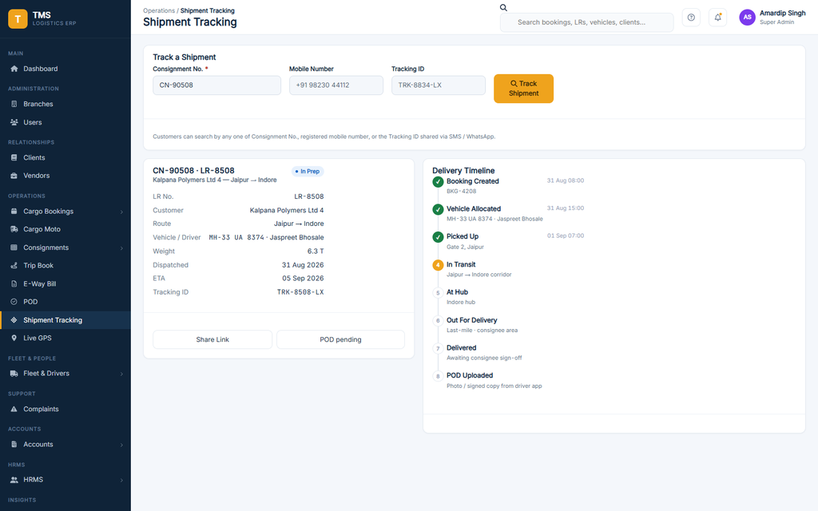

Shipment tracking. Search by consignment number, the customer’s registered mobile, or the tracking ID sent by SMS.

Search by consignment number, the customer’s registered mobile number, or the tracking ID that was shared with them. **Share Link** produces a read-only link you can send the consignee — it shows status and ETA only, never pricing and never their other shipments.

## 3.6 Step 6 · Collect the proof of delivery

**Operations → POD**

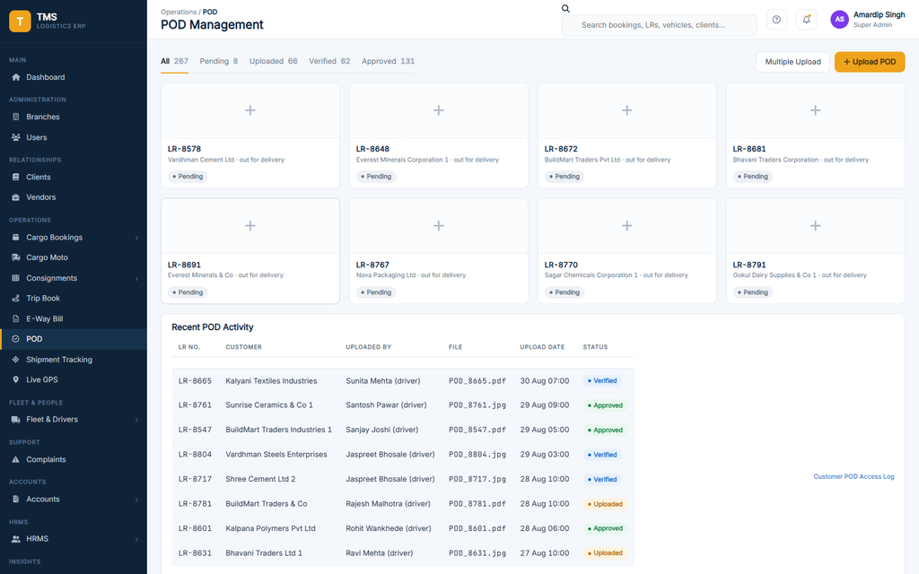

POD management. Tiles show each consignment’s proof-of-delivery status; the dashed ones are still outstanding.

The POD is the consignee’s signature confirming they received the goods. It moves through four states:

**Pending** → **Uploaded** → **Verified** → **Approved**

The driver or vendor uploads a photo or scan; ops verifies it is legible and matches; a supervisor approves it.

**This matters commercially, not just operationally.** You cannot invoice a consignment until its POD is at least *Verified* — see Why did it say no?

## 3.7 Step 7 · Raise the invoice

**Accounts → Invoices & Billing**

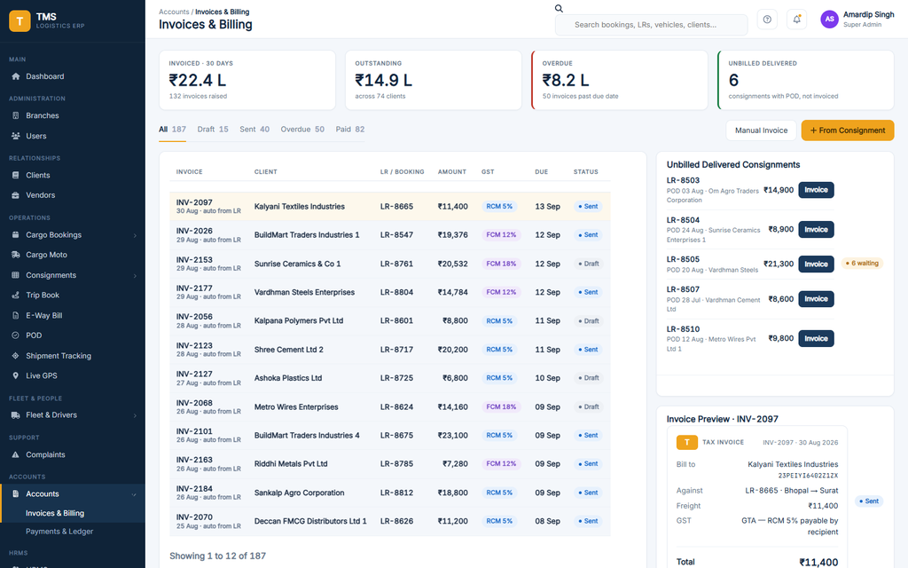

Invoices. The Unbilled Delivered queue on the right lists deliveries with a POD that have not been billed yet.

The panel on the right, **Unbilled Delivered Consignments**, is your work queue: deliveries that are complete, have a verified POD, and have not yet been billed. Click **Invoice** on any one of them, or use **+ From Consignment** to raise several at once.

### About the GST column

Every invoice shows either **RCM** or **FCM**. This is taken from the customer’s record and you cannot override it on the invoice:

- **RCM (reverse charge)** — the standard treatment for goods transport. **The carrier collects no tax.** The tax line is zero and the invoice total equals the freight; the customer pays the GST directly to the government. Most of your book will be RCM at 5%.
- **FCM (forward charge)** — you collect the tax and remit it. The invoice total is freight plus GST.

Ancillary charges raised through **Manual Invoice** — detention, demurrage, loading — are a service rather than freight, and always carry forward charge at 18% whatever the customer’s freight treatment is.

## 3.8 Step 8 · Record the payment

**Accounts → Payments & Ledger**

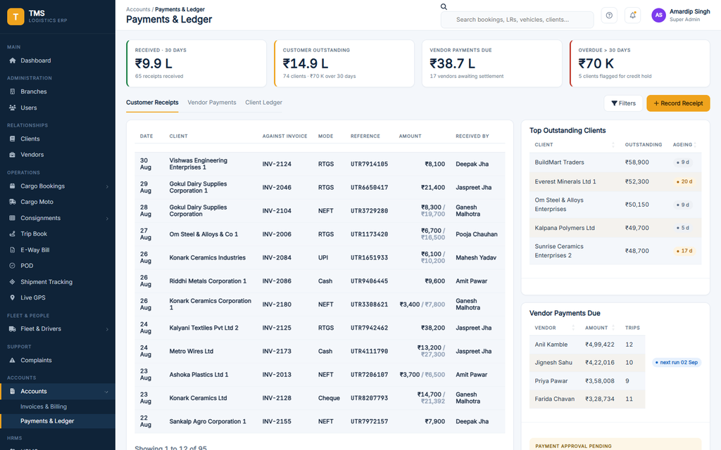

Payments and ledger. Customer receipts, vendor payouts and the client ledger in one place.

Click **+ Record Receipt** to log money received.

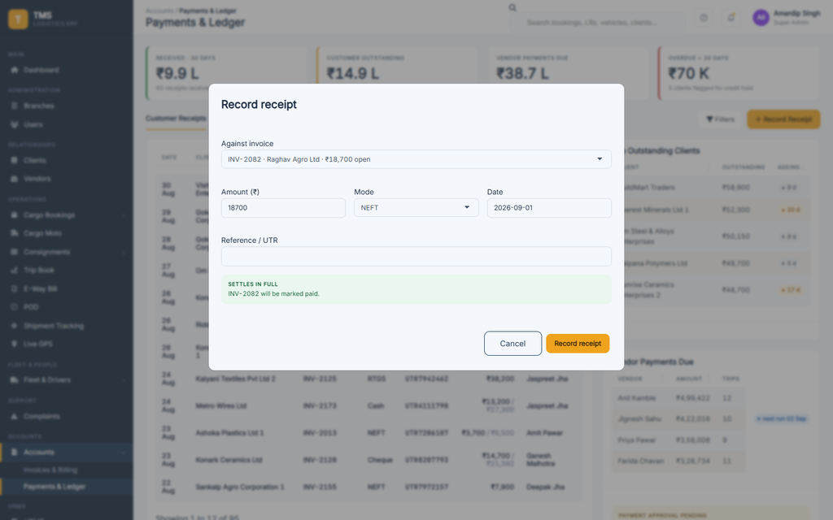

Recording a receipt. The dialog tells you what the payment will do to the invoice before you commit it.

Choose the invoice; the amount defaults to the full open balance. As you change it the dialog tells you what will happen:

- pay it in full → the invoice is marked **Paid**
- pay part → it becomes **Partially paid** and the remainder stays open
- pay more than is owed → you are warned about the over-payment

Receipts reconcile against the invoice automatically. There is no separate step to “apply” a payment, and the outstanding figures on the customer’s record, the dashboard and this screen all recompute from the same numbers.

The **Vendor Payments** tab settles the other direction — what you owe vehicle owners for the trips they ran. Payments above ₹50,000 need branch admin approval before the payment run.

# 4 Every screen, group by group

## 4.1 Administration

### Dashboard

Your landing page. Fleet snapshot on a live map, fleet status breakdown, latest complaints, deliveries trend, PODs outstanding, and a payroll summary.

If you are scoped to one branch, every figure here is your branch only.

### Branches

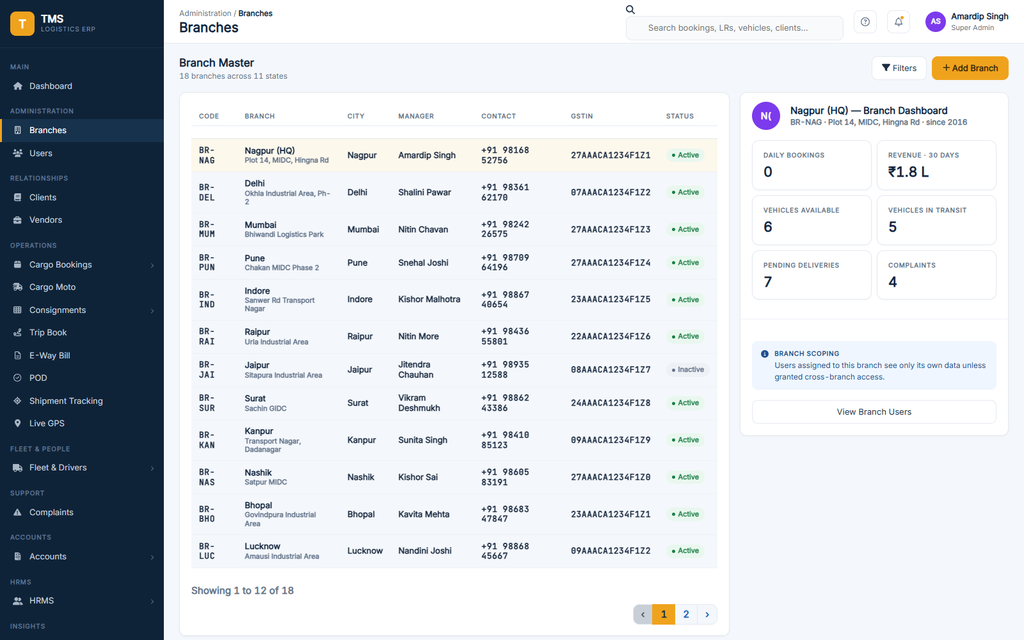

Branch master. Selecting a branch shows a mini-dashboard for it.

The branch master, with a per-branch dashboard on selection: today’s bookings, revenue, vehicle availability, pending deliveries and open complaints — all computed live, so this and the operations screens can never disagree.

### Users

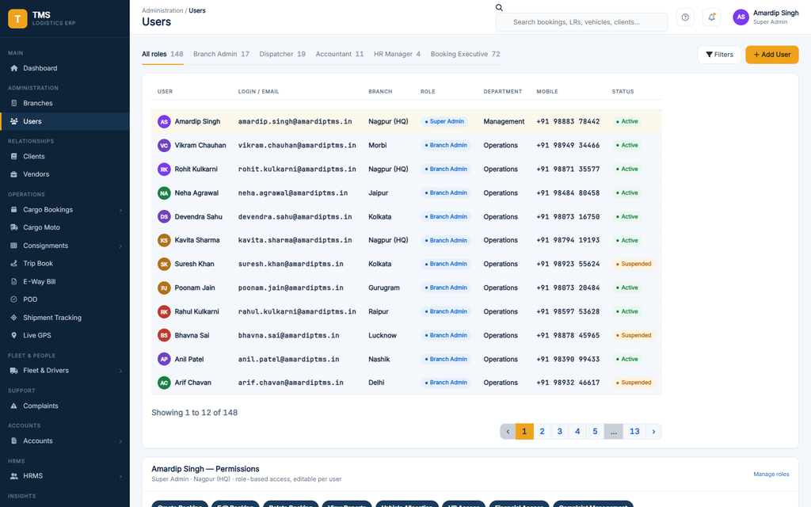

User administration, with the capability strip for the selected user.

Internal logins. Selecting a user shows what their role permits — create bookings, allocate vehicles, see financials, and so on. Those capabilities come from the role’s entry in the permission matrix; to change them, change the role under **System → Security & Roles**.

New users are created with a temporary password that must be changed at first sign-in. Tick **cross-branch access** only when someone genuinely needs to see beyond their own branch.

## 4.2 Relationships

### Clients

The customer master. Each record carries billing and delivery addresses, credit limit, **GST treatment** (which flows onto every booking and invoice) and a 360° view with consignment and payment history.

Outstanding balance is calculated from unpaid invoices, never stored — it cannot go stale when a payment lands.

### Vendors

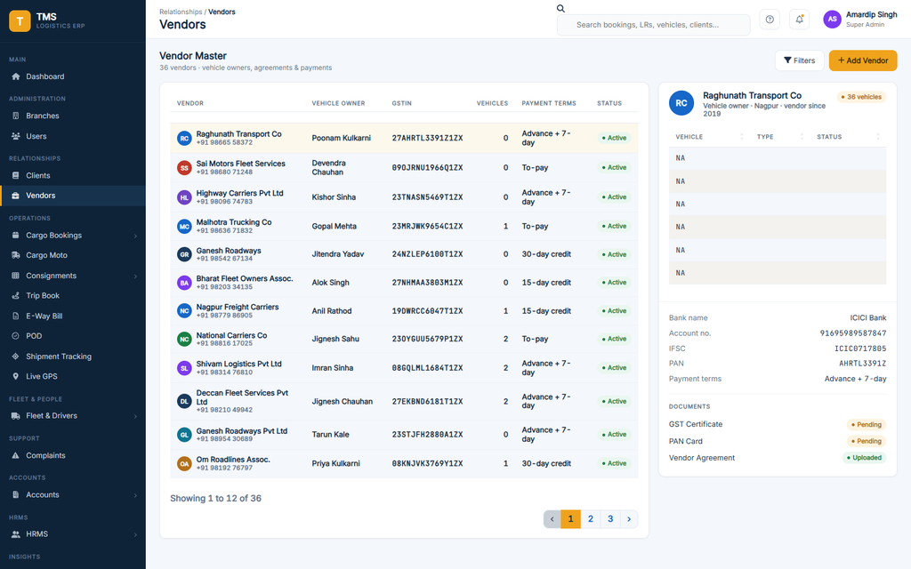

Vendor master. Vendors own vehicles you run; the panel shows their fleet, bank details and document status.

Vehicle owners who run trips for you. The panel shows the vehicles registered to them, their bank details for settlement, document status (agreement, PAN, GST certificate) and what they are currently owed.

## 4.3 Operations

### Cargo Bookings

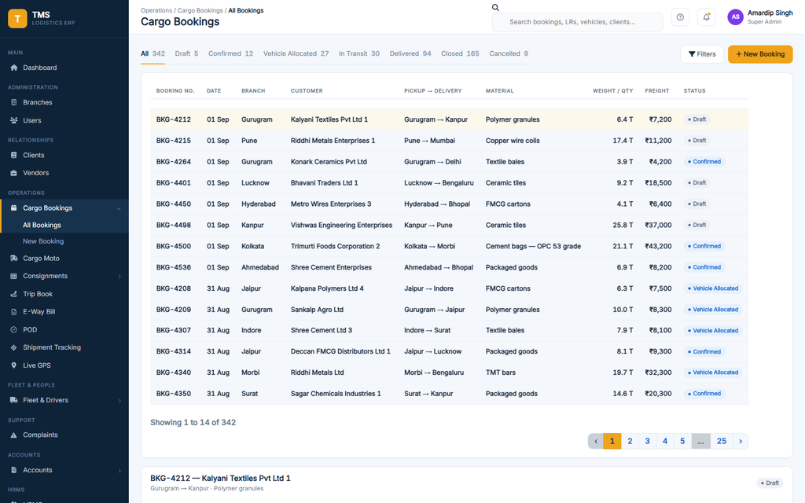

The booking register. Tabs filter by lifecycle stage; selecting a row shows the money and the vehicle assigned to it.

The register of everything ordered. The tabs across the top filter by lifecycle stage — **Draft, Confirmed, Vehicle Allocated, In Transit, Delivered, Closed, Cancelled** — with a count on each, so you can see the shape of the pipeline before clicking into it.

Select a row and a strip appears underneath showing the charge breakdown and, once allocated, the trip, vehicle, driver and LR. A booking that has not been allocated says so and points you at Cargo Moto.

This is the screen to reach for when a customer rings up about an order: filter or search, click the row, and everything about that job is in front of you.

### Trip Book

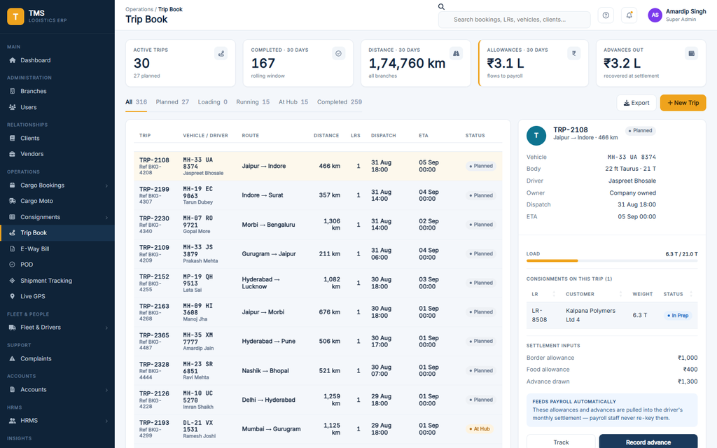

The Trip Book. One vehicle and driver, one route, with the allowances that flow into payroll.

A **trip** is one vehicle and one driver moving between two points. It is created for you when you allocate a vehicle, and it is where two things live that matter elsewhere:

- **Allowances** — a fixed border and food allowance per trip, which payroll pulls automatically into the driver’s monthly settlement.
- **Advances** — the float the driver drew for tolls, fuel and food, recovered at settlement. Record one with **Record advance** on the trip panel.

A trip also groups consignments, which is how consolidated loads are tracked.

If a payroll figure ever looks wrong, this is where to check its provenance.

## 4.4 Fleet & People

### Vehicles

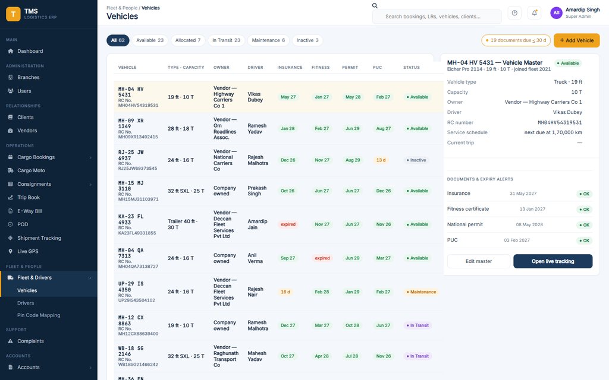

Vehicle master with document expiry surveillance.

The fleet register. Four statutory documents are tracked per vehicle — **insurance, fitness, national permit and PUC** — and each shows a colour-coded expiry badge: green in date, amber within 30 days, red expired.

**An expired document blocks allocation.** Keeping these current is what keeps trucks earning.

### Drivers

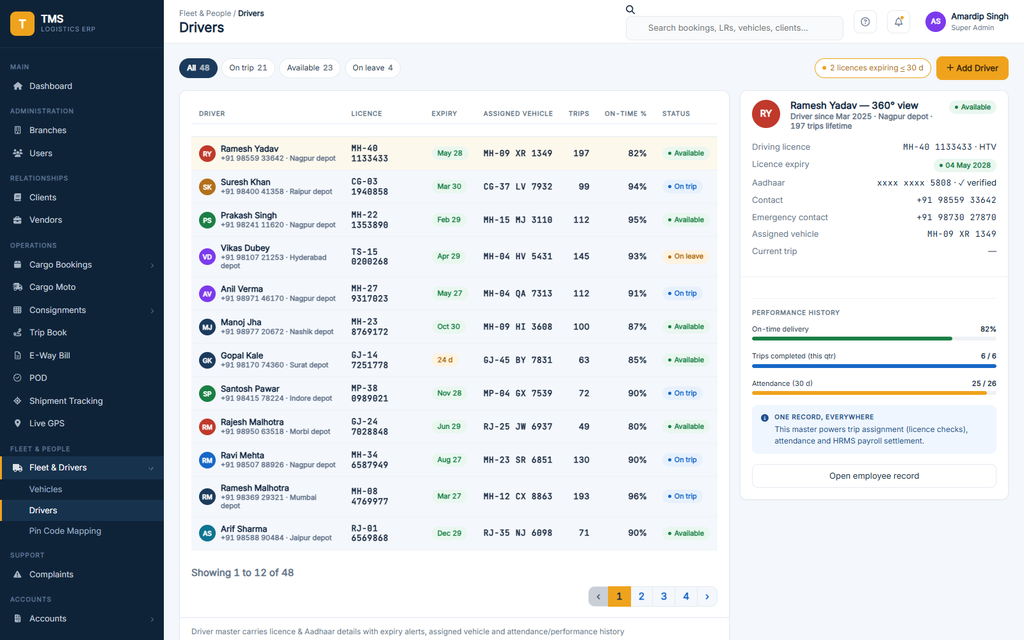

Driver master. Licence, performance and the current trip in one view.

Licence details with expiry alerting, assigned vehicle, depot, and performance history — on-time delivery, trips completed this quarter, attendance.

**A driver is an employee.** This screen is the driving-specific extension of their HR record, not a separate person. To add a driver, the person must already exist under **HRMS → Employees**; the form will tell you so.

### Pin Code Mapping

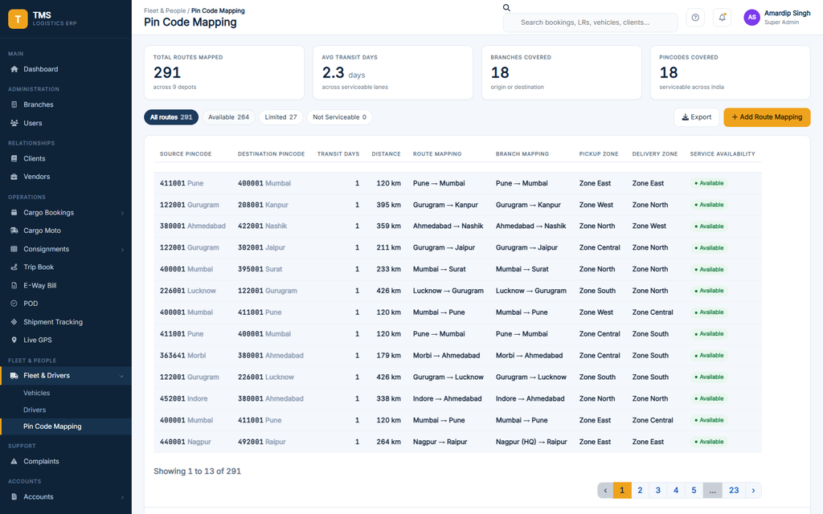

The route master. Transit-day promises and serviceability come from here.

Which lanes you serve, how long they take, and which depots a load routes through. This is what the booking form checks when it tells you a lane is serviceable and how many days to promise.

Three availability states: **Available**, **Limited** (longer transit, fewer departures) and **Not Serviceable**. Adding a lane here makes it quotable immediately.

## 4.5 Support

### Complaints

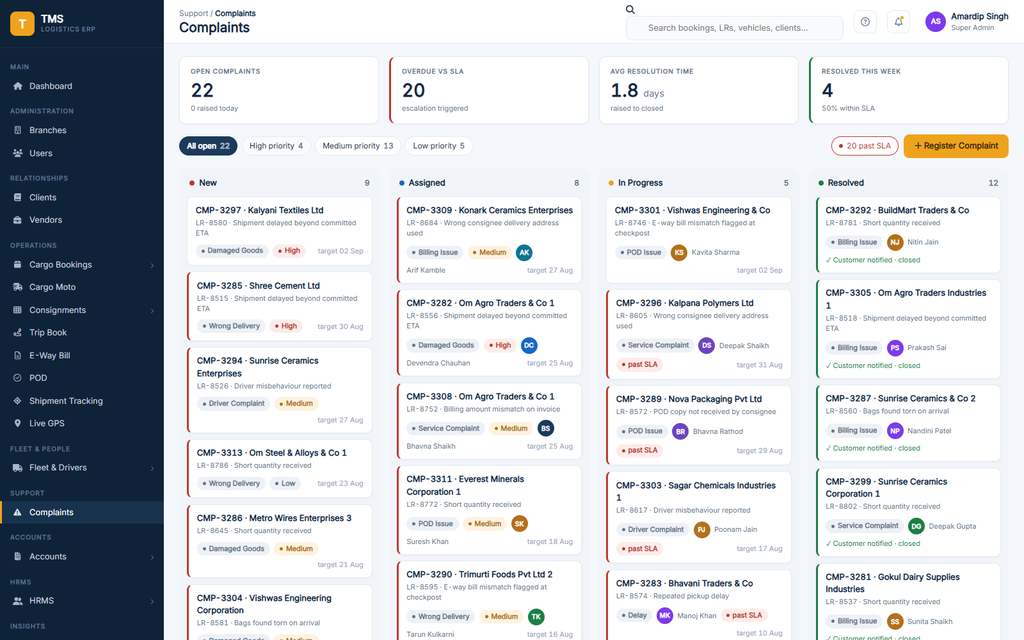

The complaints board, tracked against SLA.

A board running **New → Assigned → In Progress → Resolved**, with an SLA of two days from being raised (one day for high priority). Cards past SLA get a red stripe and the count appears in the header.

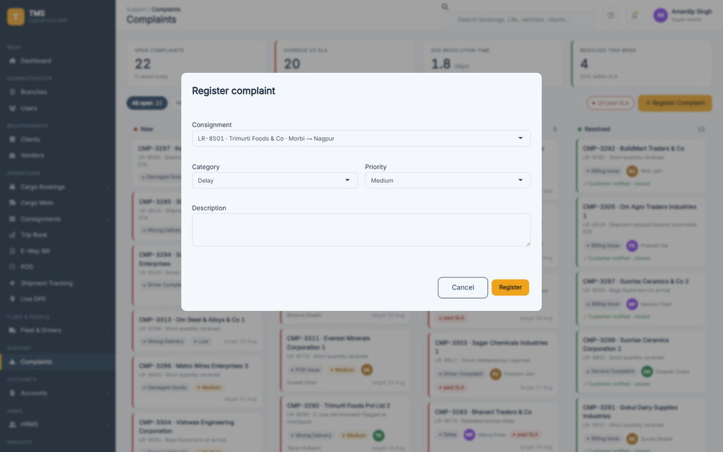

Registering a complaint against a consignment.

Register a complaint against a specific consignment so it is linked to the job it concerns. Resolving one requires a resolution note — you cannot close a ticket silently.

## 4.6 HRMS

### Employees

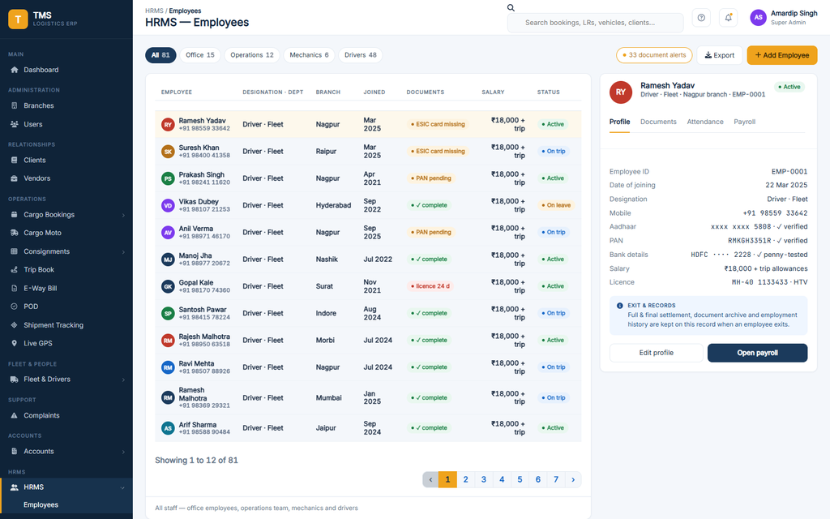

The staff register — office, operations, mechanics and drivers in one master.

Everyone on the payroll. The tabs on a selected employee cover profile, documents, attendance and payroll. Document alerts flag missing paperwork and expiring licences.

### Attendance & Leave

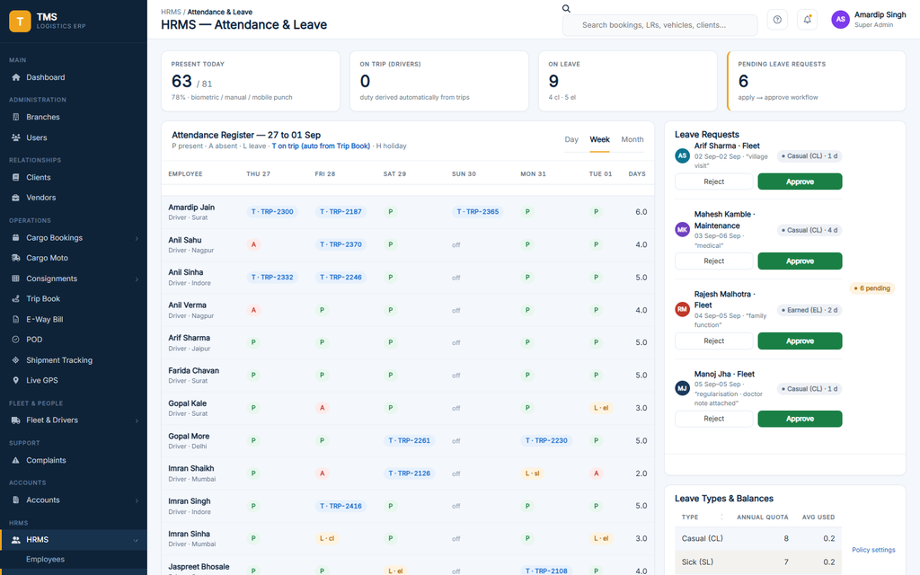

The attendance register. Blue T entries are drivers on trips, filled in automatically.

A day/week/month register using: **P** present, **A** absent, **L** leave, **T** on trip, **H** holiday.

**Drivers do not punch in.** A driver’s duty day comes from the Trip Book — if they were on a trip, that day is marked **T** automatically. Nobody on the road gets marked absent for failing to clock in.

Leave requests appear on the right for approval. If a driver has a trip booked inside the requested dates, the request is flagged so you check the roster before approving. Approving a request writes the leave days into the register, which is what payroll then reads.

### Payroll

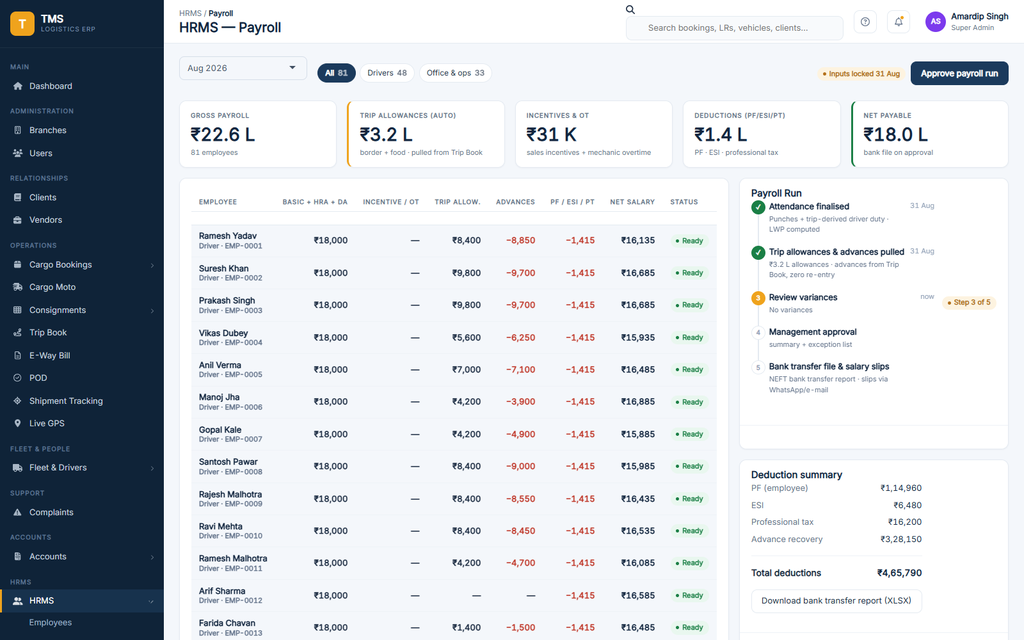

The payroll run. Trip allowances and advances are pulled from the Trip Book, not re-typed.

Payroll runs for the **month that has closed**, not the one in progress — attendance has to be final and allowances totalled before anyone can be paid. On the 1st of September you are working on August.

The **Trip Allowances (auto)** column is the point of the screen: those figures come from the Trip Book and nobody re-keys them. Advances are recovered the same way.

Deductions applied are PF at 12% of basic, ESI where the salary is within the coverage ceiling, and professional tax.

The run moves through five steps shown on the right. Anyone with a settlement variance is held back and listed at step 3; approving the run pays everyone else and leaves the exceptions for follow-up.

## 4.7 Insights

### Reports & Analytics

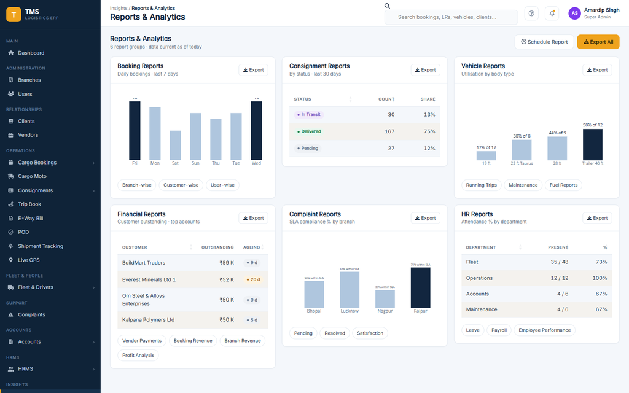

Six report groups, each exporting to Excel.

Six groups — bookings, consignments, vehicles, financial, complaints and HR. Every one exports to Excel, and every figure is computed live from operational data rather than a nightly snapshot, so an exported number always matches what was on screen.

**Schedule Report** records a recurring delivery, but reports will only actually be sent once an email gateway is connected.

## 4.8 Portals

Three read-mostly dashboards for three audiences.

### Branch Dashboard

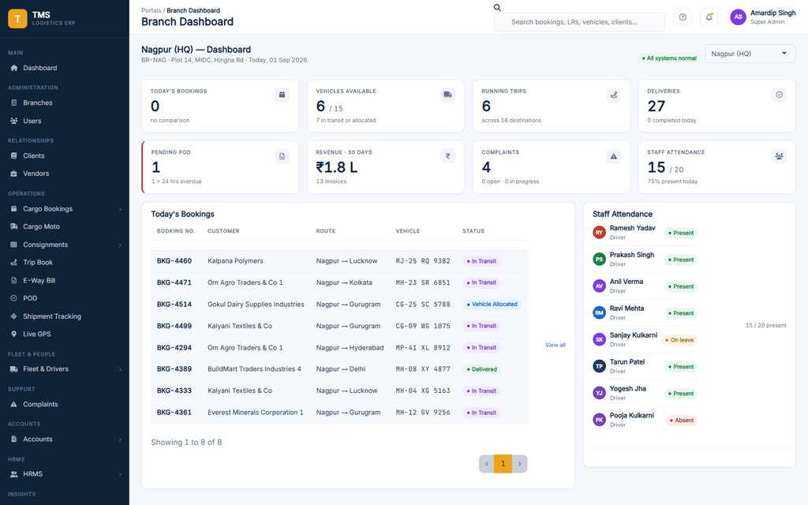

The branch dashboard — one branch’s day at a glance.

Today’s operating picture for a single branch: bookings, vehicle availability, running trips, deliveries, POD backlog, revenue, complaints and staff attendance. Users with cross-branch access get a branch switcher.

### Customer Dashboard

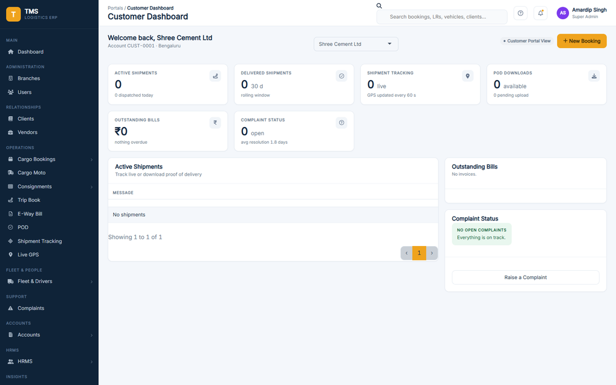

What a customer sees: their shipments, their bills, their complaints — and nobody else’s.

A customer’s self-service view: active shipments with live tracking, POD downloads, outstanding bills and complaint status.

A customer signed in to this portal can only ever see **their own** rows. That restriction is applied to the data itself, not by hiding buttons.

### Vendor Dashboard

[figure not shown]

The vendor view: assigned trips, POD obligations, pending payments and fleet compliance.

For vehicle owners: trips assigned to them, PODs they owe, payments pending, and whether their fleet documents are in order.